# 3: Regression (1)

## Concepts

Let’s say we have two variables, height and weight.

We measure 100 people’s height and weight.

Do you expect a relationship between height and weight in the data?

What kind of relationship? How would you describe it?

## Concepts

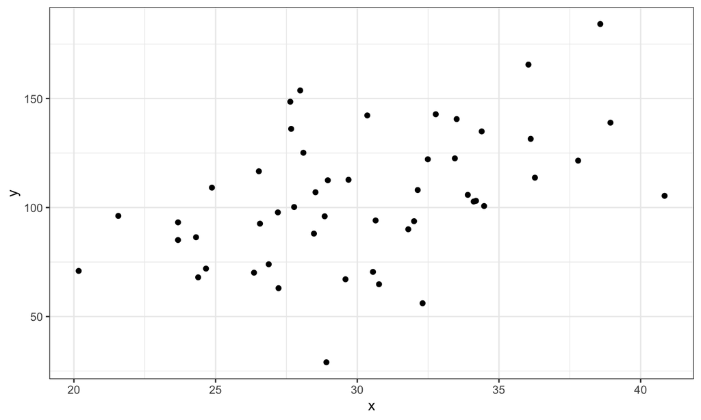

## Concepts

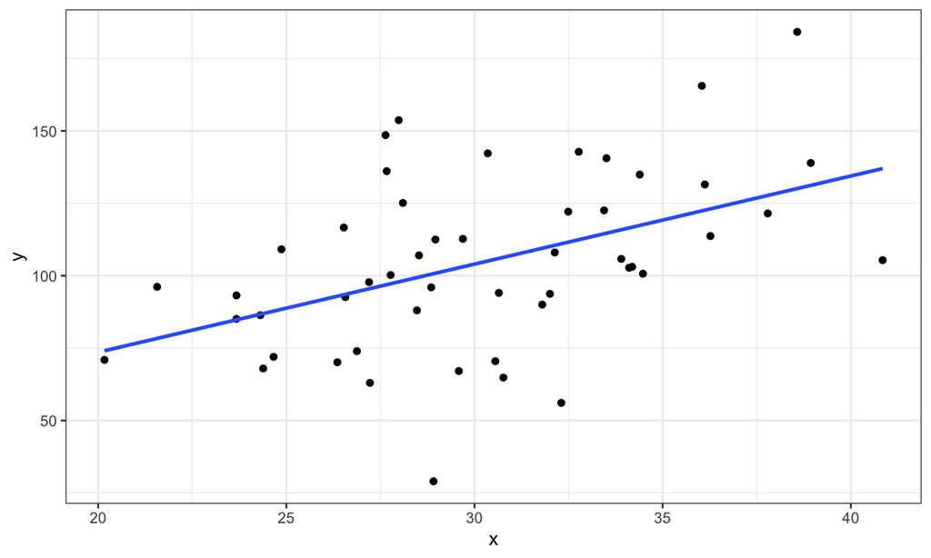

## Concepts

- How does *x* affect *y*? (simple regression)
- Given *x*, what value of *y* would you expect?
- Two main questions about estimated value of *y*:
  - What info goes into calculating it?
  - How close is this to the real value?

## Concepts

https://justinsulik.shinyapps.io/linear_regression_demo/

- Intercept
- Slope
- (Residual) error

## Concepts

- To be clear: this isn’t what you feed into the regression. It’s what the regression tells you, given some data
- y = intercept + b*x + e
- (we’ll add some subtlety to this soon)

## How does it do that? A visual analogy

[video not shown]

## How does it do that? More specific

*One* way: ordinary least squares

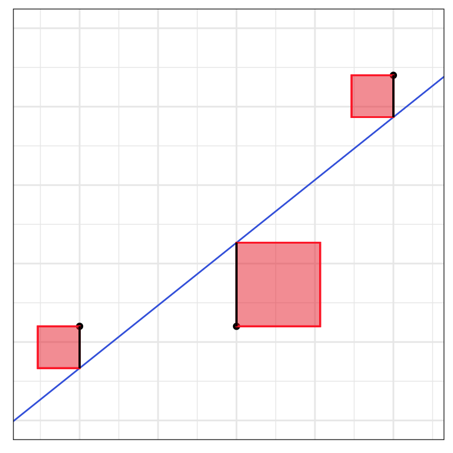

## Some simple examples - fake data

```r
faux_data <- rnorm_multi(varnames = c("outcome", "predictor"),
                  n = 100,
                  mu = c(0, 0),
                  sd = c(2, 3),
                  r = c(0.5),
                  empirical = TRUE)
```

What are you expecting the intercept to be? The beta/slope?

## Some simple examples - fake data

```r
mod1 <- lm(outcome~predictor, faux_data)
summary(mod1)
```

```
##
## Call:
## lm(formula = outcome ~ predictor, data = faux_data)
##
## Residuals:
##     Min      1Q  Median      3Q     Max
## -4.8836 -1.1398  0.2633  1.0477  4.0110
##
## Coefficients:
##              Estimate Std. Error t value Pr(>|t|)
## (Intercept) 6.095e-18  1.741e-01   0.000        1
## predictor   3.333e-01  5.832e-02   5.715 1.18e-07 ***
## ---
## Signif. codes:  0 '***' 0.001 '**' 0.01 '*' 0.05 '.' 0.1 ' ' 1
##
## Residual standard error: 1.741 on 98 degrees of freedom
## Multiple R-squared:   0.25,  Adjusted R-squared:  0.2423
## F-statistic: 32.67 on 1 and 98 DF,  p-value: 1.18e-07
```

**What would you tweak in the faux data to get a beta of 0.5?**

## Some simple examples - fake data

**Play around with the parameters for faux_data, to see how this affects the model output**

```r
faux_data <- rnorm_multi(n = 100,
                  mu = c(0, 0),
                  sd = c(2, 3),
                  r = c(0.5),
                  varnames = c("outcome", "predictor"),
                  empirical = TRUE)

faux_data %>%
  lm(outcome~predictor,data=.) %>%
  summary

ggplot(faux_data,
  aes(x=predictor, y=outcome)) +
  geom_point() +
  stat_smooth(method=lm)
```

## Do the specific numbers matter?

```r
lm(weight_kg~height_cm,weight_data) %>% summary
```

```
##
## Call:
## lm(formula = weight_kg ~ height_cm, data = weight_data)
##
## Residuals:
##      Min       1Q   Median       3Q      Max
## -11.8714  -2.9635  -0.2546   2.7604  14.6175
##
## Coefficients:
##              Estimate Std. Error t value Pr(>|t|)
## (Intercept) -51.69528    4.60952  -11.21   <2e-16 ***
## height_cm     0.62582    0.02975   21.04   <2e-16 ***
## ---
## Signif. codes:  0 '***' 0.001 '**' 0.01 '*' 0.05 '.' 0.1 ' ' 1
##
## Residual standard error: 4.215 on 329 degrees of freedom
## Multiple R-squared:  0.5736, Adjusted R-squared:  0.5723
## F-statistic: 442.5 on 1 and 329 DF,  p-value: < 2.2e-16
```

## Do the specific numbers matter?

```r
lm(weight_lbs~height_inches,weight_data) %>% summary
```

```
##
## Call:
## lm(formula = weight_lbs ~ height_inches, data = weight_data)
##
## Residuals:
##     Min      1Q  Median      3Q     Max
## -26.172  -6.533  -0.561   6.086  32.226
##
## Coefficients:
##                Estimate Std. Error t value Pr(>|t|)
## (Intercept)   -113.9685    10.1622  -11.21   <2e-16 ***
## height_inches    3.5044     0.1666   21.04   <2e-16 ***
## ---
## Signif. codes:  0 '***' 0.001 '**' 0.01 '*' 0.05 '.' 0.1 ' ' 1
##
## Residual standard error: 9.292 on 329 degrees of freedom
## Multiple R-squared:  0.5736, Adjusted R-squared:  0.5723
## F-statistic: 442.5 on 1 and 329 DF,  p-value: < 2.2e-16
```

## Do the specific numbers matter?

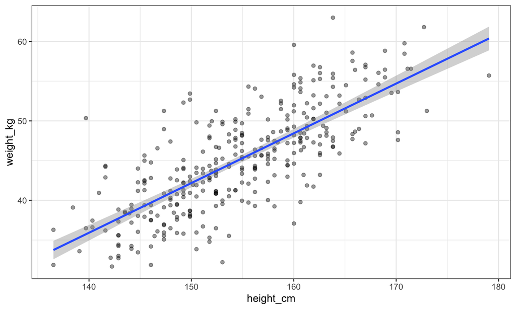

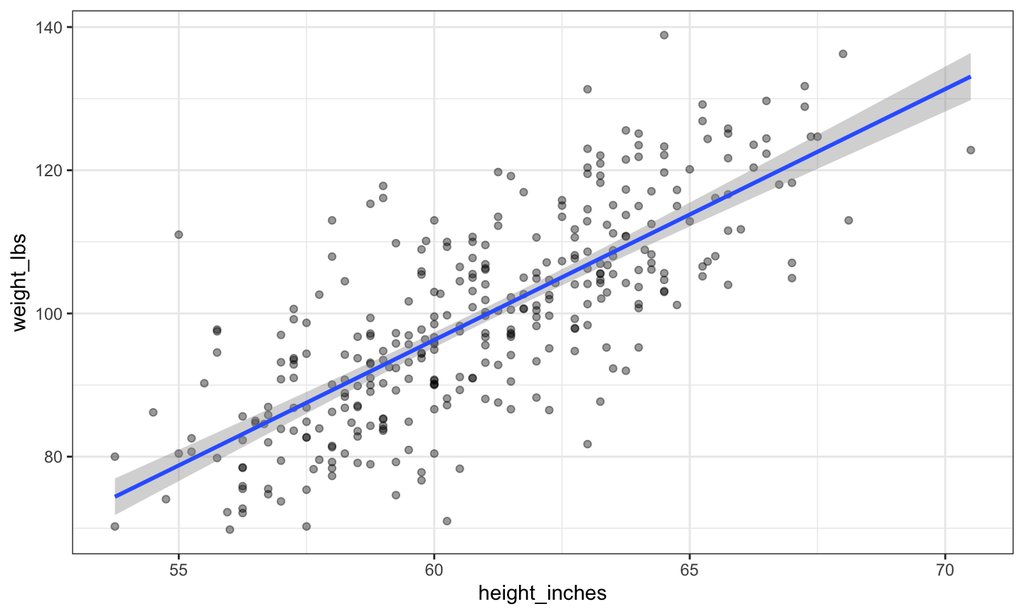

## What about the t & p values?

Go check the two models. See what changes vs. stays the same.

beta: sensitive to scale of variables?

std. error: sensitive to scale of variables?

**What about their ratio? manually calculate beta/se**

## Changing your data without changing your conclusions

```r
cor.test(weight_data$height_cm, weight_data$weight_kg)
```

```
##
##  Pearson's product-moment correlation
##
## data:  weight_data$height_cm and weight_data$weight_kg
## t = 21.036, df = 329, p-value < 2.2e-16
## alternative hypothesis: true correlation is not equal to 0
## 95 percent confidence interval:
##  0.7072852 0.7998416
## sample estimates:
##       cor
## 0.7573416
```

## Changing your data without changing your conclusions

**let’s take a moment to see what `scale()` does**

```r
weight_data %>%
  mutate_if(is.numeric, scale) %>%
  lm(weight_kg ~ height_cm,data=.) %>%
  summary
```

```
##
## Call:
## lm(formula = weight_kg ~ height_cm, data = .)
##
## Residuals:
##      Min       1Q   Median       3Q      Max
## -1.84200 -0.45982 -0.03951  0.42830  2.26810
##
## Coefficients:
##               Estimate Std. Error t value Pr(>|t|)
## (Intercept) -2.880e-16  3.595e-02    0.00        1
## height_cm    7.573e-01  3.600e-02   21.04   <2e-16 ***
## ---
## Signif. codes:  0 '***' 0.001 '**' 0.01 '*' 0.05 '.' 0.1 ' ' 1
##
## Residual standard error: 0.654 on 329 degrees of freedom
## Multiple R-squared:  0.5736, Adjusted R-squared:  0.5723
## F-statistic: 442.5 on 1 and 329 DF,  p-value: < 2.2e-16
```

## Changing your data without changing your conclusions

- Why was the intercept negative?
- What do you think the intercept means below?

```r
weight_data %>%
  mutate(height_cm = scale(height_cm, scale=FALSE)) %>%
  lm(weight_kg~height_cm,.) %>%
  summary
```

```
##
## Call:
## lm(formula = weight_kg ~ height_cm, data = .)
##
## Residuals:
##      Min       1Q   Median       3Q      Max
## -11.8714  -2.9635  -0.2546   2.7604  14.6175
##
## Coefficients:
##             Estimate Std. Error t value Pr(>|t|)
## (Intercept) 45.14828    0.23168  194.88   <2e-16 ***
## height_cm    0.62582    0.02975   21.04   <2e-16 ***
## ---
## Signif. codes:  0 '***' 0.001 '**' 0.01 '*' 0.05 '.' 0.1 ' ' 1
##
## Residual standard error: 4.215 on 329 degrees of freedom
## Multiple R-squared:  0.5736, Adjusted R-squared:  0.5723
## F-statistic: 442.5 on 1 and 329 DF,  p-value: < 2.2e-16
```

## Am I doing this right?

- Always plot your data

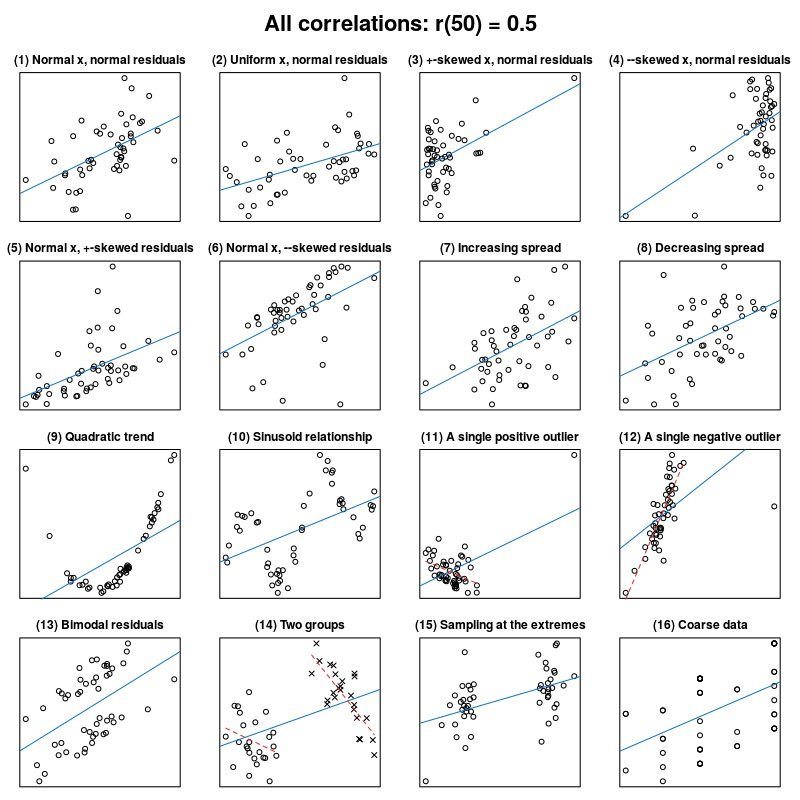

## Am I doing this right?

- Always plot your data

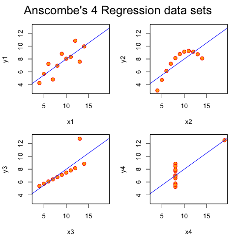

## Assumptions

1: the relationship between outcome and predictor(s) is assumed to be linear

2: the residuals are normally distributed

3: the residuals have a constant variance

4: the residuals are independent

Some of these can be read off plots; others need thinking about

## Assumptions 1: are we looking at a linear relationship?

- Should see: flat horizontal line

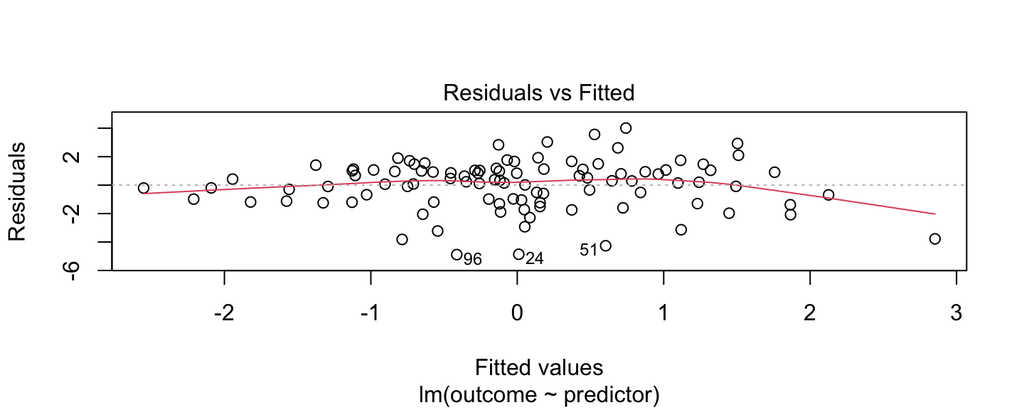

```r
plot(mod1, which=1)
```

## Assumptions 2: Are the residuals normally distributed?

Common myth: the outcome must be normally distributed. False! the residuals must be normally distributed.

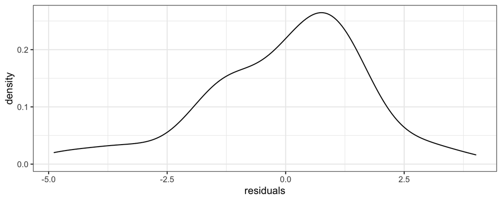

```r
data.frame(residuals = resid(mod1)) %>%
  ggplot(aes(x=residuals)) +
  geom_density()
```

## Assumptions 2: Are the residuals normally distributed?

Common myth: the outcome must be normally distributed. False! the residuals must be normally distributed.

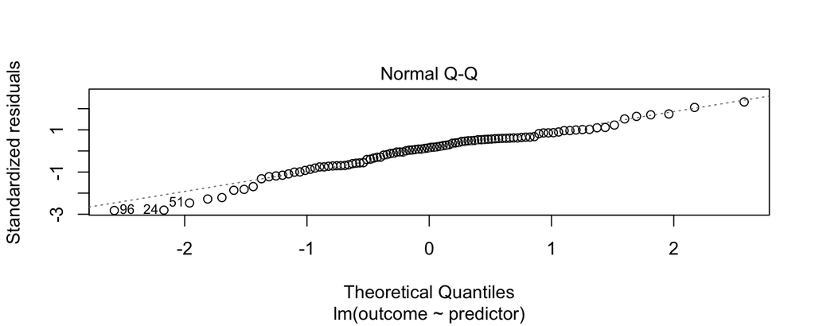

```r
plot(mod1, which=2)
```

## Assumption 4: the residuals are independent

This needs thinking about

How could the residual for one data point be related to the residual for another data point?

## Next up

- Today:
  - What about categorical predictors?
  - Multiple predictors?
  - Easy cases of non-linearity.
- Tomorrow:
  - More problematic cases of non-linearity
  - What to do if there’s a serious problem with non-normality?
  - What to do if residuals aren’t independent?